# Example Markdown

Gabriela Lopez-Gonzalez

Tuesday, January 10, 2017

**Template to describe data recording, cleaning and analysis**

Data was collected following Gentry floristic protocol. Details of data collection can be found in http://www.mobot.org/MOBOT/Research/gentry/transect.shtml

**Data curation and quality control**

Data collected was formatted following the RAINFOR protocol and uploaded to ForestPlots.net database and application. After the upload, the Quality Control protocol wizard was applied to look for outliers. http://www.ForestPlots.net.

**Data “cleaning” and transformation**

For this example we’re going to use data included in the trees dataset. We begin by loading the `trees` data frame. Type the following in your console to load the data:

```r
data(trees)
```

The packages use are dplyr and ggplot2.

```r
library(dplyr)
library(ggplot2)
library(statsr)
```

The variables included in the trees dataset are tree diameter in inches, height in feet and volume of timber in cubic ft. Diameter was transformed to cm and height to meters as this are the units used to model the relationship between height and diameter.

```r
trees <- trees %>%
  mutate(diam_cm = Girth*2.54)
trees <- trees %>%
  mutate(height_m = Height*0.3048)
```

The relationship between diameter and height is shown in the figure below.

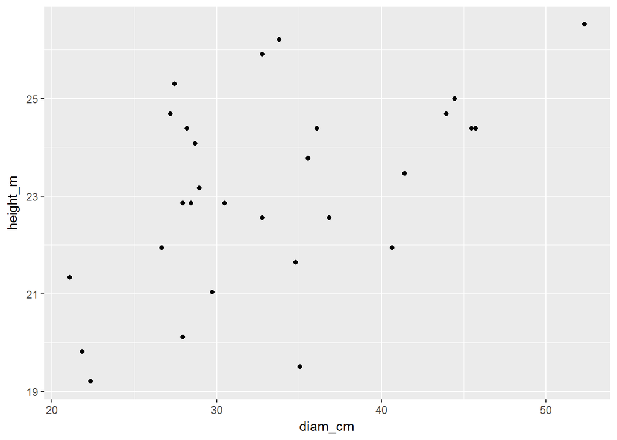

```r
ggplot(data = trees, aes(x = diam_cm, y = height_m)) +
  geom_point()
```